# Assignment 7 - ALY2100 CRN SEC 02 Fall 2023 CPS

Student: Margarita Kholostova

Instructor: Vladimir Shapiro

Date: October 22, 2023

## Introduction

In the modern age, digital items, whether they be electronic gadgets, software applications, or online services, play a pivotal role in shaping our daily interactions and activities. Recognizing the importance of managing and organizing information about these items, this assignment introduces a Digital Item Management System.

Our exploration begins from a simple observation: as the digital landscape expands, there arises a significant need for systematic methods to catalog and retrieve data about various digital items. This necessity isn't limited to just electronic devices but extends to any digital product or service that users might interact with.

Throughout this assignment, we will delve into the framework of our proposed system. We'll start with a high-level overview, understanding its primary objectives and goals. As we move forward, we'll touch upon its architectural design, emphasizing its modularity and scalability, ensuring it can be adapted or extended to various digital items or applications in the future. The assignment aims to offer a holistic view of the system's functionalities and the foundational principles guiding its design and implementation (OpenAI, 2023).

## Analysis

### Task 1

Use one of the programs you wrote in the previous assignments, adding at least one String type, exception handlers, and control flow mechanism. Make sure to display user-friendly messages and not the raw Python error ones.

Alternatively, you can create a puzzle game using all you learned so far PLUS the string type, making sure to add exception handlers and a control flow mechanism.

```python
"""
This program is designed to manage and store details about electronic items, specifically generic gadgets and laptops.

Features:
1. Abstract Base Class - 'ElectronicItem':
    - Represents a general electronic item with attributes like brand, model, price, and warranty period.
    - Allows displaying the item's information in a user-friendly format.

2. Parent Class - 'Gadget':
    - Derived from 'ElectronicItem'.
    - Represents a general gadget.
    - Allows setting and getting attributes (price, warranty, brand, model).
    - Provides functionality to save gadget information to a CSV file named 'data.csv'.

3. Child Class - 'Laptop':
    - Derived from 'Gadget'.
    - Represents a laptop with additional attributes like RAM, processor, and storage.
    - Allows setting and getting these new attributes.
    - Overrides the display function to include the laptop-specific details.
    - Provides functionality to save laptop information to a CSV file named 'laptop_data.csv'.

Utility Functions:
1. 'get_non_empty_input' - Repeatedly prompts the user for input until a non-empty response is provided.
2. 'display_file_content' - Displays the content of a specified file.
3. 'display_csv_as_table' - Displays the content of a CSV file in a tabular format.

Main Flow:
- The program prompts the user to enter details for either a gadget or a laptop.
- Once the user has entered all the details, they have the option to save this data to a CSV file.
- The user can continue to enter details for multiple items.
- On exiting (by typing 'q'), the program displays the saved details in a tabular format from the CSV files.

Note: The CSV file handling ensures that data is appended without overwriting previous entries, and appropriate headers are added if the file is new.
"""


from typing import Any, Optional
import os

#abstract class
class ElectronicItem:
    def __init__(self, brand:str, model:str, price: Optional[float] = None,warranty_period: Optional[float] = None)-> None: #price & warranty are not required to be known at the moment of object creation (default value None)
        self.brand = brand
        self.model = model
        self.price = price #in dollars float
        self.warranty_period = warranty_period #in months

    def display_info(self) -> None:
        print("Here is the data that you entered:")
        print(f"Manufacturer: {self.brand}")
        print(f"Model Number: {self.model}")
        if self.price is not None:
            print(f"Retail Price: ${self.price:.2f}")
        else:
            print("Retail Price: Not provided")
        if self.warranty_period is not None:
            print(f"Warranty Period: {self.warranty_period} months")
        else:
            print("Warranty Period: Not provided")
        print("\n")




#parent class
class Gadget(ElectronicItem):

    def __init__(self, brand:str, model:str, price: Optional[float] = None,warranty_period: Optional[float] = None) -> None:
        super().__init__( brand, model, price, warranty_period)

    def set_price(self, price: float) -> None:
        if price < 0:
            raise ValueError("Price cannot be negative")
        self.price = price


    def set_warranty(self, warranty:float) -> None:
        if warranty < 0:
            raise ValueError("Warranty period cannot be negative")
        self.warranty_period = warranty

    def get_brand(self)->str:
        return self.brand

    def get_model(self)->str:
        return self.model

    def get_price(self)->Optional[float]:
        return self.price

    def get_warranty_period(self)-> Optional[float]:
        return self.warranty_period

    def save_to_file(self):
        filename = 'data.csv'
        try:
            file_exist = os.path.isfile(filename) and os.path.getsize(filename) > 0  # check if file exists and is not empty

            with open(filename, 'a') as file:
                if not file_exist:
                    file.write("Brand, Model, Price, Warranty (in month)\n")

                # write data
                file.write(f"{self.brand}, {self.model}, {self.price}, {self.warranty_period}\n")
        except IOError as e:
            print(f"Error saving to file {e}")

        return filename  # return the filename after saving



#child class
class Laptop(Gadget):


    def __init__(self, brand:str, model:str, RAM:int, processor:str, storage:int, price: Optional[float]= None,warranty_period: Optional[float] = None) -> None:
        super().__init__(brand, model, price, warranty_period) # no need to specify types again when calling parents method
        self.RAM = RAM
        self.processor = processor
        self.storage = storage

    #getter & setters for earlier not mentioned RAM and Storage

    def set_RAM(self, RAM) -> None:
        if RAM <= 0:
            raise ValueError("RAM cannot be negative or equal to zero")
        self.RAM = RAM

    def set_processor(self, processor) -> None:
        self.processor = processor

    def set_storage(self, storage) -> None:
        if storage <= 0:
            raise ValueError("Storage cannot be negative or equal to zero")
        self.storage = storage

    def get_RAM(self) -> int:
        return self.RAM

    #storage will be stored in GB
    def get_storage(self) ->int:
        return self.storage

    def get_processor(self) ->str:
        return self.processor

    def display_info(self)-> None:
        super().display_info()  # calling the display_info from the parent class to display common attributes
        print(f"RAM: {self.RAM} GB")
        print(f"Processor: {self.processor}")
        print(f"Storage: {self.storage} GB")
        print("\n")



    def save_to_file(self):
        filename = "laptop_data.csv"
        try:
            file_exists_laptop = os.path.isfile(filename) and os.path.getsize(filename) > 0

            with open(filename, 'a') as file:
                if not file_exists_laptop:
                    file.write("Brand,Model,RAM,Processor,Storage,Price,Warranty \n")

                file.write(f"{self.brand},{self.model},{self.RAM},{self.processor},{self.storage},{self.price},{self.warranty_period}\n")
        except IOError as e:
            print(f"Error saving to the file: {e}")

        return filename #return filename after saving


def get_non_empty_input(prompt: str) -> str:
    """Prompt the user for input until they provide a non-empty response."""
    while True:
        user_input = input(prompt).strip()
        if user_input:
            return user_input
        print("Input cannot be empty. Please try again.")


#the format of displaying in csv was chosen, but function stays in case of needed change
def display_file_content(filename: str):
    """Displays the content of a specified file."""
    try:
        with open(filename, 'r') as file:
            print(f"\nContents of {filename}:")
            print(file.read())
    except IOError as e:
        print(f"Error reading from file {filename}: {e}")

def display_csv_as_table(filename: str):
    """Displays the content of a specified file the table format."""
    try:
        with open(filename, 'r') as file:
            lines = file.readlines()

            # Display header
            headers = lines[0].strip().split(',')
            header_format = '|'.join([' {:<15} '] * len(headers))
            print(header_format.format(*headers))
            print('-' * (15 * len(headers) + len(headers) - 1))

            # Display rows
            for line in lines[1:]:
                row = line.strip().split(',')
                print(header_format.format(*row))

    except IOError as e:
        print(f"Error reading from file {filename}: {e}")



def main():

    saved_files = [] #store filenames where data were stored


    while True:

        choice = input("Please choose an item type:\n1. Gadget\n2. Laptop\nEnter your choice (1/2) or 'q' to quit: ")

        if choice.lower() == 'q':
            print("Quitting...\n")
            for filename in saved_files:
                if os.path.getsize(filename) > 0:
                     display_csv_as_table(filename)
            break
        elif choice not in ['1', '2']:
            print("Invalid choice. Please try again.")
            continue

        try:
            if int(choice) == 1:
                brand = get_non_empty_input("Enter gadget brand: ")
                model = get_non_empty_input("Enter model name: ")
                try:
                    price = float(input("Enter price of the gadget or press enter to skip: "))
                except ValueError:
                    price = None

                try:
                    warranty_period = float(input("Enter warranty in months or press enter to skip: "))
                except ValueError:
                    warranty_period = None

                gadget = Gadget(brand, model, price, warranty_period)

                #diplaying input info is default
                gadget.display_info()

                save_to_file = input("Do you want to save displayed information? yes/no ")

                if save_to_file.lower().startswith("y"):
                    saved_filename = gadget.save_to_file()
                    if saved_filename not in saved_files:
                        saved_files.append(saved_filename)
                else:
                    print("Data not saved.")

            elif int(choice) == 2:
                brand = get_non_empty_input("Enter laptop brand: ")
                model = get_non_empty_input("Enter model name: ")

                try:
                    price = float(input("Enter price of the gadget or press enter to skip: "))
                except ValueError:
                    price = None

                try:
                    warranty_period = float(input("Enter warranty in months or press enter to skip: "))
                except ValueError:
                    warranty_period = None

                RAM = int( get_non_empty_input("Enter amount of RAM in the laptop: "))
                processor = get_non_empty_input("Enter a processor of the laptop: ")
                storage = int(get_non_empty_input("Enter amount of storage in GB: "))


                laptop = Laptop(brand, model, RAM, processor, storage,price, warranty_period)

                #diplaying input info is default
                laptop.display_info()

                save_to_file_laptop = input("Do you want to save displayed information? yes/no ")

                if save_to_file_laptop.lower().startswith("y"):
                    saved_filename = laptop.save_to_file()
                    if saved_filename not in saved_files:
                        saved_files.append(saved_filename)
                else:
                    print("Data not saved.")



            else:
                print("Invalid choice. Please try again.")

        except ValueError as ve:
            print(f'Error: {ve}. Please try again.')

if __name__ == "__main__":
    main()
```

```
Please choose an item type:
1. Gadget
2. Laptop
Enter your choice (1/2) or 'q' to quit:
Invalid choice. Please try again.
Please choose an item type:
1. Gadget
2. Laptop
Enter your choice (1/2) or 'q' to quit: 1
Enter gadget brand: Apple
Enter model name:
Input cannot be empty. Please try again.
Enter model name: iPhone X
Enter price of the gadget or press enter to skip: 234
Enter warranty in months or press enter to skip:
Here is the data that you entered:
Manufacturer: Apple
Model Number: iPhone X
Retail Price: $234.00
Warranty Period: Not provided


Do you want to save displayed information? yes/no y
Please choose an item type:
1. Gadget
2. Laptop
Enter your choice (1/2) or 'q' to quit: 1
Enter gadget brand:
Input cannot be empty. Please try again.
Enter gadget brand: Google
Enter model name: EarBuds
Enter price of the gadget or press enter to skip: 59.99
Enter warranty in months or press enter to skip: 2
Here is the data that you entered:
Manufacturer: Google
Model Number: EarBuds
Retail Price: $59.99
Warranty Period: 2.0 months


```

[output cut: 66 more lines]

```
Do you want to save displayed information? yes/no y
Please choose an item type:
1. Gadget
2. Laptop
Enter your choice (1/2) or 'q' to quit: q
Quitting...

 Brand           |  Model          |  Price          |  Warranty (in month)
---------------------------------------------------------------
 Apple           |  iPhone X       |  234.0          |  None
 Google          |  EarBuds        |  59.99          |  2.0
 Brand           | Model           | RAM             | Processor       | Storage         | Price           | Warranty
---------------------------------------------------------------------------------------------------------------
 Dell            | XPS             | 32              | i5              | 256             | None            | None
 Apple           | Macbook         | 32              | M2              | 1000            | 2300.0          | 24.0
```

### Task 2

A. Build a flow chart of a game, any business process, or a math problem with user interaction that uses the file input/output features we covered in this module and the relevant ones from previous modules, including classes, functions, lists, and str methods.

Note: YOU MUST VALIDATE ALL USER INPUT AND ALWAYS GIVE FRIENDLY ERROR MESSAGES. By this point, you should have some validation functions that you can use and reuse throughout the course; it is also essential to have a control loop (outer loop) so that the player can quit when they want. Explain the functionality of your code/program in the text cells or comments.

### Flowchart

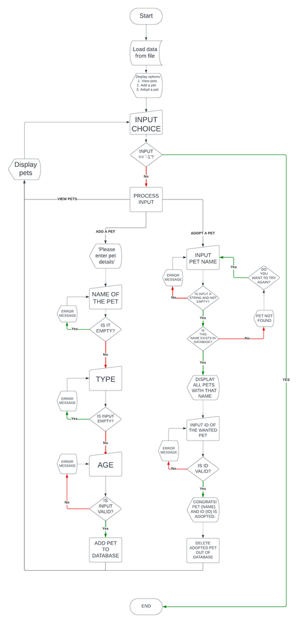

Figure 1. Flowchart representing pet adoption app

# Conclusions

Throughout this week's exploration into the Digital Item Management System, we have journeyed through the intricate realms of object-oriented programming (OOP). A key takeaway has been the profound understanding of abstract classes, which served as a foundational blueprint for our digital items. By leveraging the power of inheritance, we seamlessly extended functionalities across gadgets and specific product types, like laptops, demonstrating the principle of reusability inherent in OOP.

Furthermore, the assignment shed light on the principle of encapsulation, ensuring that data and methods associated with an object are shielded, thus promoting data integrity. Additionally, the introduction of conditional I/O operations exemplified the flexibility of modern systems, allowing users to opt for data storage based on their preferences.

In retrospect, the development of the Digital Item Management System not only served as a testament to the robustness and versatility of OOP principles but also underscored the importance of user-centric design in software development. As we wrap up, it's evident that the learned concepts, from abstract classes to encapsulation, play a pivotal role in crafting efficient, modular, and scalable applications, preparing us for more complex challenges in the future.

# References

1. Guttag, J. V. (2021). Introduction to computation and programming using python, third edition: With application to computational modeling and Understanding Data. MIT Press.
2. Kalb, I. (2018). Learn to program with python 3: A step-by-step guide to programming. Apress.
3. McBride, M. (2022, July 25). Using optionals in Python. Medium. https://medium.com/geekculture/using-optionals-in-python-412c34fa799e
4. OpenAI. (n.d.). Chatgpt. ChatGPT. https://openai.com/chatgpt
5. Python dictionary. Programiz. (n.d.). https://www.programiz.com/python-programming/dictionary
6. Python Inheritance W3Schools. Python inheritance. (n.d.). https://www.w3schools.com/python/python_inheritance.asp
7. Real Python. (2023, October 2). What does if **name** == “**main**” do in python? https://realpython.com/if-name-main-python/
8. Typing - support for type hints. Python documentation. (n.d.). https://docs.python.org/3/library/typing.html